# Project 2 - CMSC320

Student: Mads Andersen

UID: 119377475

```python
import sqlite3
import pandas
from matplotlib import pyplot as plt
import seaborn as sns
import numpy as np
sns.set_style("darkgrid")
```

```python
#This is only for running it in Colab
from google.colab import drive
drive.mount('/content/drive')
```

```python
#Acces the sqlite_file
# If you need to run this cell in colab insert your own directory to the sqlite file
sqlite_file = "/content/drive/MyDrive/CMSC320-Intro_data_science/project2/lahman2014.sqlite"
conn = sqlite3.connect(sqlite_file)
```

# Part 1: Wrangling

## Problem 1:

First of the correct table has to be made using the SQL query. To do this the WITH clause will be used to create two temporary tables, containing the correct collumns, then we will create a third and final table, from these tables.

```python
# Write SQL query
winning_p_query = """ WITH sal(teamID, yearID,salary) AS
                      (SELECT teamID, yearID, sum(salary)
                      FROM Salaries
                      GROUP BY teamID, yearID),
                      t(teamID,yearID,lgID,franchID,rank,W,G,w_p) AS
                      (SELECT Teams.teamID, Teams.yearID,Teams.lgID, Teams.franchID, Teams.rank, Teams.W,Teams.G, ((Teams.W*1.0/Teams.G)*100)
                      FROM Teams
                      GROUP BY teamID, yearID)
                      SELECT sal.teamID, sal.yearID,salary,lgID,franchID,rank,W,G,w_p
                      FROM sal,t
                      WHERE
                      t.teamID == sal.teamID AND t.yearID == sal.yearID
                      """
df = pandas.read_sql(winning_p_query, conn)
```

```python
df.head()
```

|  | teamID | yearID | salary | lgID | franchID | rank | W | G | w_p |
| --- | --- | --- | --- | --- | --- | --- | --- | --- | --- |
| 0 | ATL | 1985 | 14807000.0 | NL | ATL | 5 | 66 | 162 | 40.740741 |
| 1 | BAL | 1985 | 11560712.0 | AL | BAL | 4 | 83 | 161 | 51.552795 |
| 2 | BOS | 1985 | 10897560.0 | AL | BOS | 5 | 81 | 163 | 49.693252 |
| 3 | CAL | 1985 | 14427894.0 | AL | ANA | 2 | 90 | 162 | 55.555556 |
| 4 | CHA | 1985 | 9846178.0 | AL | CHW | 3 | 85 | 163 | 52.147239 |

So as can be seen we are only including data from 1985, which is because there is no salary data before 1985. So what this means is, that when the third and final table is created we only include rows who have the same teamID and yearID, and since the salary table *(sal)* does not include any data from before 1985, this will not be included in the final table. This is also what happens in an inner join in SQL.

# Part 2: Exploratory Data Analysis

## Problem2

First of let us show the distribution of payrolls, across the teams by plotting the histogram. Then a boxplot of each year will be plotted.

```python
plt.rcParams["figure.figsize"] = (10,5) #Set figSize
```

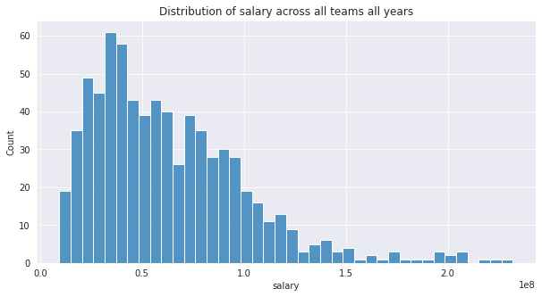

```python
# Use seaborn to plot histogram of the salary across all teams in 40 bins.
sns.histplot(df[df["yearID"]>=1990]["salary"],bins = 40)
plt.title("Distribution of salary across all teams all years")
```

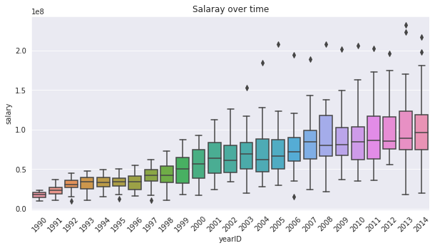

```python
#Make a plot which is time-dependent.
fig,ax = plt.subplots(1)
dat = df[df["yearID"]>=1990]
sns.boxplot(data = dat,x = "yearID",y = 'salary')
plt.xticks(rotation=45)
plt.title("Salaray over time")
```

## Question 1

Another thing to notice about the boxplots, are that from 2003 and upwards, it seems like there are outliers each year, and especially outliers who are hihger than everyone else. This could indicate that some teams starting getting really rich compared to the rest of the league.

# Problem 3

Even though the boxplots do show the tendency of a bigger spread in salary over time, we could show this even more explicitly

Code which shows increase in in spread and mean per year across teams:

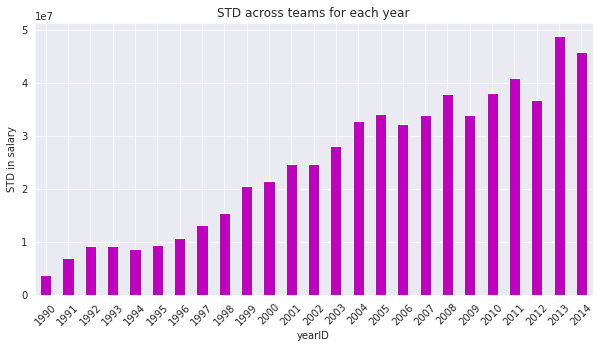

```python
fig,ax = plt.subplots(1)
dat = df[df["yearID"]>=1990]
dat = dat.groupby("yearID")["salary"].std()
dat.plot.bar(color = "m",rot=45)
ax.set_title("STD across teams for each year")
ax.set_ylabel("STD in salary")
```

As can be seen in the plot above, the STD does increase by quite a lot over the years, which could be an indication that the inequality between teams, was increasing, as stated. However as will also be adressed later, the salaries are generaly increasing, so it is hard to conclude if the std increases due to increase in salary or increase in inequality.

I also claimed earlier that, the payroll in genereal seemed to increase, to do another plot to verify this, we can plot the mean payroll per year. Since the median is already shown in the boxplot we will only plot mean.

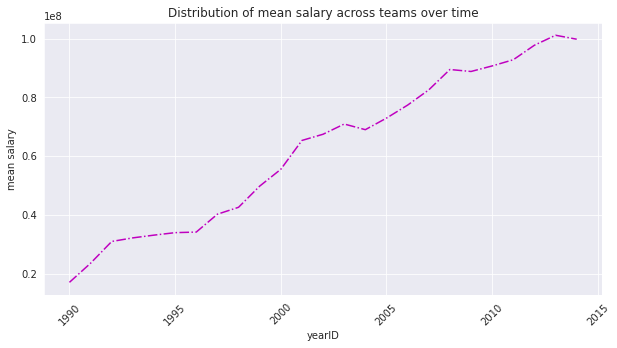

```python
fig,ax = plt.subplots(1)
dat = df[df["yearID"]>=1990]
datMean = dat.groupby("yearID")["salary"].mean()
datMean.plot.line(color = "m",linestyle = 'dashdot',rot=45)
ax.set_title("Distribution of mean salary across teams over time")
ax.set_ylabel("mean salary")
```

# Problem 4

Now we will investigate the question of: "Correlation between payroll and winning percentage". First of the yearID variable is discretized using the cut functionality.

```python
dat = df[df["yearID"]>=1990].copy() #copy so python will not give warning
dat["yearID"] = pandas.cut(dat["yearID"],bins = 5)
dat.head()
```

|  | teamID | yearID | salary | lgID | franchID | rank | W | G | w_p |
| --- | --- | --- | --- | --- | --- | --- | --- | --- | --- |
| 130 | ATL | (1989.976, 1994.8] | 14555501.0 | NL | ATL | 6 | 65 | 162 | 40.123457 |
| 131 | BAL | (1989.976, 1994.8] | 9680084.0 | AL | BAL | 5 | 76 | 161 | 47.204969 |
| 132 | BOS | (1989.976, 1994.8] | 20558333.0 | AL | BOS | 1 | 88 | 162 | 54.320988 |
| 133 | CAL | (1989.976, 1994.8] | 21720000.0 | AL | ANA | 4 | 80 | 162 | 49.382716 |
| 134 | CHA | (1989.976, 1994.8] | 9491500.0 | AL | CHW | 2 | 94 | 162 | 58.024691 |

Now do a group by to sort yearID and team id also get the mean. Then get it all back into a dataframe.

```python
grouped_salary = dat.groupby(["yearID","teamID"])["salary"].mean().to_frame()
grouped_wp = dat.groupby(["yearID","teamID"])["w_p"].mean().to_frame()
```

```python
grouped_wp['salary'] = grouped_salary['salary']
grouped = grouped_wp.copy()
grouped = grouped.dropna()
gp = grouped.reset_index(level=['yearID', 'teamID']) #Reset so we can index
gp["yearID"] = gp["yearID"].astype(str)
```

Now we need to plot the data, individually. First we index each period utilizing pandas logical indexing. Then each period will be plotted using a scatter plot. I will be using sns because it formats it nicer, and it still works well with the pyplot library. Also a regression line will be fitted and plotted for each of the periods, in order to make it easier to see who performs better than the rest meassured on w_p as function of total payroll.

Also this plot will include the names of the team for each data point. I escpecially marked the Oakland team with red, because this will prove usefull in the next task in this assignment.

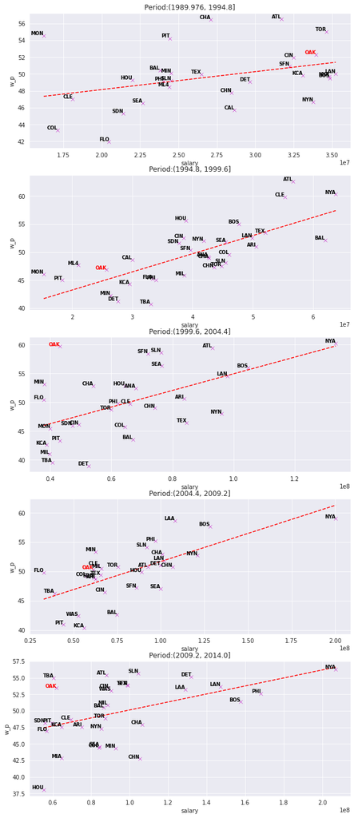

```python
plt.rcParams["figure.figsize"] = (10, 25)
fig,ax = plt.subplots(5)
gp = grouped.reset_index(level=['yearID', 'teamID'])
for (i,period) in enumerate(gp["yearID"].unique()):
  current = gp[gp['yearID'] == period]
  sns.scatterplot(data = current,x = "salary", y = "w_p",ax=ax[i],color = "m",marker = 'x')

  #Plot regression line
  line = np.polyfit(current['salary'],current['w_p'],1)
  f = np.poly1d(line)
  vals = np.linspace(current.salary.min(),current.salary.max(),num=50)
  ax[i].plot(vals,f(vals),linestyle='dashed',c = 'r')

  #Anotate
  for line in range(0,len(current)):
    if current.teamID.iloc[line] == 'OAK':
      ax[i].text(current.salary.iloc[line]+0.2,
                current.w_p.iloc[line]+0.1,
                current.teamID.iloc[line],
                horizontalalignment='right',
                size='small',
                color='red',
                weight='semibold')
    else:
      ax[i].text(current.salary.iloc[line]+0.2,
                current.w_p.iloc[line]+0.1,
                current.teamID.iloc[line],
                horizontalalignment='right',
                size='small',
                color='black',
                weight='semibold')

  ax[i].set_title(f'Period:{str(period)}')
```

## Question 2

From the previous plots, it is quite obvious that Oakland performs way better than the rest in the period 2000-2004, which is when they pioneered the use of datascience in Baseball. Also they are spending a lot less money to actually get those wins.

Also it is worth noting that in the 1990-1995 period, Oakland was doing pretty well, however they were also spending quite a lot of money. Another thing to say about Oakland, is that they are always above the regression line, meaning that even if they aren't winning a lot, fx in period: 1995-2000, they were also not spending a lot of money.

# Part 3 - Data transformation

## Problem 5

Now we will standardize all of the payrolls with respect to the year they were recorded in. I assume that we are still working with the period 1990-2014

```python
data = df[df["yearID"] >= 1990].copy()
```

```python
#Do a group by, and then do the reset_index to make it possible to index the colloumns.
#Groupby is needed to get the average salary for each team in a given year
data = data.groupby(["yearID","teamID"]).mean().reset_index(level=['yearID', 'teamID'])

#Find values needed for normalization
mean_salary = data.groupby(["yearID"])["salary"].mean().to_frame()
mean_salary["Std"] = data.groupby(["yearID"])["salary"].std()

# The code belowe is a one liner to apply the normalization of the salary
data["Standardized_salary"] = data.apply(lambda x: (x["salary"]-mean_salary.loc[x["yearID"]]["salary"])/mean_salary.loc[x["yearID"]]["Std"], axis = 1)
data.head()
```

|  | yearID | teamID | salary | rank | W | G | w_p | Standardized_salary |
| --- | --- | --- | --- | --- | --- | --- | --- | --- |
| 0 | 1990 | ATL | 14555501.0 | 6.0 | 65.0 | 162.0 | 40.123457 | -0.667275 |
| 1 | 1990 | BAL | 9680084.0 | 5.0 | 76.0 | 161.0 | 47.204969 | -1.959861 |
| 2 | 1990 | BOS | 20558333.0 | 1.0 | 88.0 | 162.0 | 54.320988 | 0.924213 |
| 3 | 1990 | CAL | 21720000.0 | 4.0 | 80.0 | 162.0 | 49.382716 | 1.232198 |
| 4 | 1990 | CHA | 9491500.0 | 2.0 | 94.0 | 162.0 | 58.024691 | -2.009859 |

## Problem 6

Now the plots from before will be recreated with the new variable. Do also note that to make comparison between years easier, I made the x-axis the same for all of the plot, using the sharex functionality.

```python
data["yearID"] = pandas.cut(data["yearID"],bins = 5)
grouped_salary = data.groupby(["yearID","teamID"])["Standardized_salary"].mean().to_frame()
grouped_wp = data.groupby(["yearID","teamID"])["w_p"].mean().to_frame()
grouped_wp['Standardized_salary'] = grouped_salary['Standardized_salary']
grouped = grouped_wp.copy()
grouped = grouped.dropna()
gp = grouped.reset_index(level=['yearID', 'teamID']) #Reset so we can index
gp["yearID"] = gp["yearID"].astype(str)
```

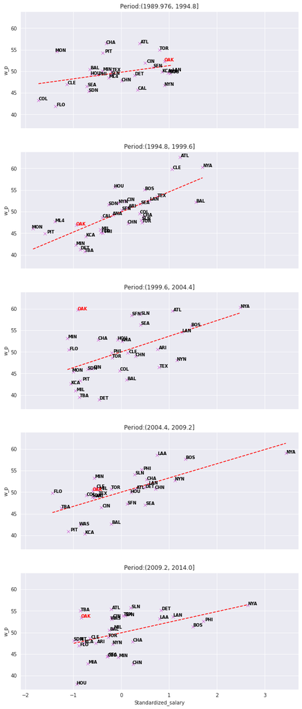

```python
plt.rcParams["figure.figsize"] = (10, 25)
fig,ax = plt.subplots(5,sharex=True,sharey = True)
gp = grouped.reset_index(level=['yearID', 'teamID'])
for (i,period) in enumerate(gp["yearID"].unique()):
  current = gp[gp['yearID'] == period]
  sns.scatterplot(data = current,x = "Standardized_salary", y = "w_p",ax=ax[i],color = "m",marker = 'x')

  #Plot regression line
  line = np.polyfit(current['Standardized_salary'],current['w_p'],1)
  f = np.poly1d(line)
  vals = np.linspace(current.Standardized_salary.min(),current.Standardized_salary.max(),num=50)
  ax[i].plot(vals,f(vals),linestyle='dashed',c = 'r')

  #Anotate
  for line in range(0,len(current)):
    if current.teamID.iloc[line] == 'OAK':
      ax[i].text(current.Standardized_salary.iloc[line]+0.2,
                current.w_p.iloc[line],
                current.teamID.iloc[line],
                horizontalalignment='right',
                size='small',
                color='red',
                weight='semibold')
    else:
      ax[i].text(current.Standardized_salary.iloc[line]+0.2,
                current.w_p.iloc[line],
                current.teamID.iloc[line],
                horizontalalignment='right',
                size='small',
                color='black',
                weight='semibold')

  ax[i].set_title(f'Period:{str(period)}')
```

## Question 3

So how did the transformation change the plots? First of the obvious change is the x-axis, where all of the data points have mean 0. That means it makes it easier for us to interpret when a team is above average payroll or below. We could have just plotted a line in problem 4 showcasing this, but this makes the plot less noisy.

Furtermore and probably most important, this allows us to compare different time periods more easily. This is because the payroll is now only described as a relative thing to the mean. The fact that they can share x-axis now, is a big contributer this comparison. Also the fact that how much you pay your players is always relative to the rest of the league, because how much a team payed their players in 1980 might be very low in the moderne era, but a huge amount back in 1980.

# Expected Wins

## Problem 7

This time we will plot all of them together, and fit the regression line to the whole data. Note also that numpy.poly1d will return a function. This will help us for calculating expected win %, since we can just call the 'f' function on whatever standardized salary we wan't to get the expected salary for.

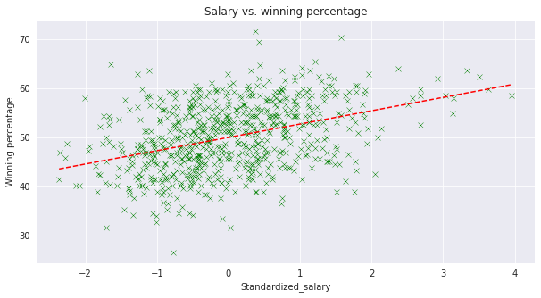

```python
plt.rcParams["figure.figsize"] = (10, 5)

fig,ax = plt.subplots(1)
sns.scatterplot(data = data,x = "Standardized_salary",y = "w_p",color = 'g',marker = 'x')
plt.title("Salary vs. winning percentage")
plt.ylabel("Winning percentage")

#Plot regression line
line = np.polyfit(data['Standardized_salary'],data['w_p'],1)
f = np.poly1d(line)
vals = np.linspace(data.Standardized_salary.min(),data.Standardized_salary.max(),num=50)
ax.plot(vals,f(vals),linestyle='dashed',c = 'r')
```

## Problem 8

Now we will compute the effeciency by using the given equation: $efficiency_{ij} = win\_pct_{ij}-expected\_win\_pct_{ij}$. Also note that now the f functionality will come in handy.

```python
# First lets recreate the dataframe with only the years without intervals:
data = df[df["yearID"] >= 1990].copy()
data = data.groupby(["yearID","teamID"]).mean().reset_index(level=['yearID', 'teamID'])
mean_salary = data.groupby(["yearID"])["salary"].mean().to_frame()
mean_salary["Std"] = data.groupby(["yearID"])["salary"].std()
data["Standardized_salary"] = data.apply(lambda x: (x["salary"]-mean_salary.loc[x["yearID"]]["salary"])/mean_salary.loc[x["yearID"]]["Std"], axis = 1)

#Define anonymous function
ef = lambda x: x["w_p"]-f(x["Standardized_salary"])
data["efficiency"] = data.apply(ef,axis = 1)
data.head()
```

|  | yearID | teamID | salary | rank | W | G | w_p | Standardized_salary | efficiency |
| --- | --- | --- | --- | --- | --- | --- | --- | --- | --- |
| 0 | 1990 | ATL | 14555501.0 | 6.0 | 65.0 | 162.0 | 40.123457 | -0.667275 | -8.046701 |
| 1 | 1990 | BAL | 9680084.0 | 5.0 | 76.0 | 161.0 | 47.204969 | -1.959861 | 2.557239 |
| 2 | 1990 | BOS | 20558333.0 | 1.0 | 88.0 | 162.0 | 54.320988 | 0.924213 | 1.813857 |
| 3 | 1990 | CAL | 21720000.0 | 4.0 | 80.0 | 162.0 | 49.382716 | 1.232198 | -3.963704 |
| 4 | 1990 | CHA | 9491500.0 | 2.0 | 94.0 | 162.0 | 58.024691 | -2.009859 | 13.513211 |

Now we will plot line describing the efficiency over time, for each of the suggested teams.

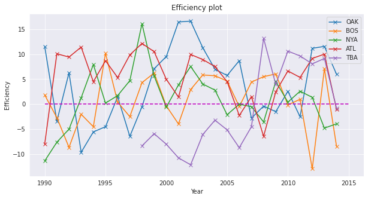

```python
for team in ['OAK', 'BOS', 'NYA', 'ATL', 'TBA']:
  team_df = data[data["teamID"] == team][['yearID',	'efficiency']]
  plt.plot(team_df['yearID'],team_df['efficiency'], 'x-')
plt.xlabel("Year")
plt.ylabel("Efficiency")
plt.title("Efficiency plot")
plt.legend(['OAK', 'BOS', 'NYA', 'ATL', 'TBA'])
plt.plot(np.linspace(1990,2015,50),[0]*50,'--',c = 'm')
```

## Question 4

As can be seen in the Money Ball years Oakland was leading the league in efficiency it however started to decline after the 2002 year and by 2004 they where no longer leading, at least among the teams we plotted. What should be remembered is that teams probably quickly caught on to the succes, and started catching up. Also one thing this plot reveals is that even though they did well in efficiency it this level was however achieved by NYA in the 98 season, however it looks like they where not able to sustain it. Another team which stands out, is the ATL team, which consistently are quite efficient, and I would argue are better than Oakland in being efficient for the entire period of 1990-2015. This could be further researched with finding the mean efficiency of both teams over the entire period.

Another intersting thing is that as long as a team is above 0, *(shown by the dotted magneta line)* the team is efficient. Meaning they are winning more games, than they were expected to, given the money they put into their payroll.